# Homework 1

### Introduction

In this homework, you will be given three questions to answer.

**How to submit:** You can submit your code using the blue **Submit** button above. This button will record your code below. Please make sure you submit your code when you are done.

**Caution:** Please *do not* change the names of any provided functions or classes within the code. Furthermore, *any code not surrounded by **#<GRADED>****#</GRADED>** tags will not be graded*. Please *do not* add or remove such tags.

# Question 1: The picture mishap

The back story: You took some photos of smiley faces a while ago and knowing about the PCA algorithm, compressed these photos. The original photos were of size $105 \times 105$ grey-scale images represented as $d = 11025$ dimensional vectors (remember the smiley faces from class!). The compressed photos were $K = 20$ dimensional each along with the projection matrix $W$ of size $11025 \times 20$ and the mean vector $\mu$ of size $11025 \times 1$.

Accidentally one night, you deleted all but one of the compressed version of the photos and all you have now is the projection matrix W, the mean vector µ and the compressed 20 dimensional vector of just the first image say $y_1$. Fortunately for you, one of your friends has printed copies of these photos. However as luck would have it, these photos were all stained with an identical stain on all of them (coffee spill over the stack of photos). To make things worse, your friend takes a picture of all these photos at an angle (in this assignment for my ease a $90$ degree angle but in general this is some unknown angle of rotation) and emails these photos over to you. So now you have these $28$ images all rotated and all with identical stain on them. Can you use your knowledge of PCA to reconstruct your favorite smiley photos?

For your convenience, below we load:

1. the projection matrix (of size $11025 \times 20$) you used into variable "Wgood"
2. the mean face you had originally computed in the vectorized format into variable "mugood"
3. The low dimensional ($20$ dimensional) representation of the first image you luckily had on you in variable "Ygood1"

# Hint:

Adding the same stain on all the images can be viewed as images all being translated by adding the stain

So you can view each $\mathbf{x}_t$ as now changes to $\mathbf{x}_t + \mathrm{stain}$.

Think of how this translation would affect the new projection matrix $W$, and the low dimensional $\mathbf{y}_t$'s

Next, the rotation of the image can be thought of as exaclty that, rotating the instances by some rotation matrix $R$. So you can think of rotation + stain as changing $\mathbf{x}_t$ to $R (\mathbf{x}_t + \mathrm{stain})$ where the rotation matrix $R$ is a valid rotation matrix with $R^\top R = R R^\top = I$. If we rotate data point, how does it affect new projection matrix $W$? How does it affect magnitude of coordinates of $\mathbf{y}_t$?

One other hint, and the only reason we need the low dimensional version of the first image: if $x$ is an eigen vector of a matrix $M$ then so is $-x$. Its like saying we can put the arrow left to right or right to left. But notice that if we flip the sign of a column of $W$, then corresponding coordinate of $\mathbf{y}_t$ is also flipped. You will need this observation and the low dimensional representation of the first image to get the right reconstruction.

```python
import numpy as np
import scipy
from scipy.sparse.linalg import eigs
from scipy.ndimage import imread
from plotly.offline import download_plotlyjs, init_notebook_mode, plot, iplot
import plotly.graph_objs as go
from PIL import Image
from IPython.display import display
init_notebook_mode(connected=True)
import sys
import csv
import numpy
import pandas as pd

sys.path.insert(0, './p01/')

Wgood  = np.genfromtxt ('data/Wgood.csv', delimiter=",")
mugood = np.genfromtxt ('data/Mugood.csv', delimiter=",")
Ygood1 = np.genfromtxt ('data/Ygood1.csv', delimiter=",")
```

# Loading images and vectorizing them

We also have below the code that will load images from the Jpeg format into the variable $X$. The variable $X$ has $28$ rows, one for each image and has $11025$ columns.

```python
%%capture --no-stdout
I = np.zeros((105,105,28))
X = np.zeros((28,11025))


# Load images and convert into vector format
for t in range(28):
    I[:,:,t] = imread("./data/badsmilie"+str(t+1)+".jpeg",flatten=True)
    X[t,:] = I[:,:,t].reshape((1,-1)).astype(float)

# now X is the data matrix and each row of X corresponds to one data point
Xhat = np.zeros((28,11025))
```

# Your Solution:

You need to provide your reconstructed smiley faces in the variable Xhat. You can provide them in the flattened (vectorized) format. We will reshape them to the 105 x 105 image below. Just make sure, that you populate your solution in variable "Xhat". It should be a $28 \times 11025$ matrix with one row for each reconstructed image.

```python
#<GRADED>
# Your solution goes below here: write your solution in the function below.
#It takes as arguments the four things given to you, 1. the projection matrix "Wgood"
#2. the mean face "mugood"
#3. The low dim representation of first image "Ygood1"
#4. and finally the set of stained rotated images X (vectorized)
# It should return a 28 x 11025 matrix of reconstructed images.

def Q1_solution(Wgood, mugood, Ygood1,X):
    Xhat = np.zeros((28,11025))

    def Rotate_90_To_Right(d):
        matrix = np.zeros((d**2,d**2))
        for i in range(d):
            for j in range(d):
                matrix[i+j*d, (i+1)*d-j-1]=1
        return matrix

    def Rotate_90_To_Left(d):
        matrix = np.zeros((d**2,d**2))
        for i in range(d):
            for j in range(d):
                matrix[(i+1)*d-j-1, i+j*d]=1
        return matrix

    R = Rotate_90_To_Right(105)

    X_rot = X.dot(R)

    mu_bad = np.mean(X_rot, axis = 0)
    Sigma_bad = np.cov(X_rot.T)
    K = 20
    E,Wbad = eigs(Sigma_bad, k = K, which = "LM")
    Wbad = np.real(Wbad)
    Ybad = (X_rot - mu_bad).dot(Wbad)

    Xhat = Ybad.dot(Wbad.T) + mugood

    return Xhat
#</GRADED>
```

# Now lets see what your reconstructions look like:

```python
Xhat = Q1_solution(Wgood,mugood,Ygood1,X)
print(Xhat.shape)
Ihat = np.zeros((105,105,28))

for t in range(28):
    # Clipping to make sure we are in range
    Ihat[:,:,t] = np.clip(Xhat[t,:].reshape((105,105)),0,255)

for R in range(28):
    print("Original no.:",R+1)
    image = Image.fromarray(I[:,:,R].astype('uint8'))
    display(image)
    print("Recovered no.:",R+1)
    image = Image.fromarray(Ihat[:,:,R].astype('uint8'))
    display(image)
```

[output not shown]

```
(28, 11025)
Original no.: 1
```

```
Recovered no.: 1
```

```
Original no.: 2
```

```
Recovered no.: 2
```

```
Original no.: 3
```

```
Recovered no.: 3
```

```
Original no.: 4
```

```
Recovered no.: 4
```

```
Original no.: 5
```

```
Recovered no.: 5
```

```
Original no.: 6
```

```
Recovered no.: 6
```

```
Original no.: 7
```

```
Recovered no.: 7
```

```
Original no.: 8
```

```
Recovered no.: 8
```

```
Original no.: 9
```

```
Recovered no.: 9
```

```
Original no.: 10
```

```
Recovered no.: 10
```

```
Original no.: 11
```

```
Recovered no.: 11
```

```
Original no.: 12
```

```
Recovered no.: 12
```

```
Original no.: 13
```

```
Recovered no.: 13
```

```
Original no.: 14
```

```
Recovered no.: 14
```

```
Original no.: 15
```

```
Recovered no.: 15
```

```
Original no.: 16
```

```
Recovered no.: 16
```

```
Original no.: 17
```

```
Recovered no.: 17
```

```
Original no.: 18
```

```
Recovered no.: 18
```

```
Original no.: 19
```

```
Recovered no.: 19
```

```
Original no.: 20
```

```
Recovered no.: 20
```

```
Original no.: 21
```

```
Recovered no.: 21
```

```
Original no.: 22
```

```
Recovered no.: 22
```

```
Original no.: 23
```

```
Recovered no.: 23
```

```
Original no.: 24
```

```
Recovered no.: 24
```

```
Original no.: 25
```

```
Recovered no.: 25
```

```
Original no.: 26
```

```
Recovered no.: 26
```

```
Original no.: 27
```

```
Recovered no.: 27
```

```
Original no.: 28
```

```
Recovered no.: 28
```

# Question 2: PCA Vs Random Projections

Your goal in this question is to generate two data sets consisting of $100$ points in $1000$-dimensions each. For each $d$-dimensional point $\mathbf{x}_t$ in the two data sets, ensure that their norm (distance to $0$) is exactly 1. We shall perform PCA and random projections on both the data sets to K = 20 dimensions. The data sets should be such that on the first one PCA outperforms random projection by a large margin and in the second, random projection outperforms PCA. To evaluate our projections we shall use the following metric on how well the projections preserve average inter point distances:

$$ \mathrm{Err}(\mathbf{y}_1,\ldots, \mathbf{y}_n) = \frac{1}{n(n − 1)/2} \sum_{i=1}^n \sum_{j=i+1}^n \left|\ \left\|\mathbf{y}_j − \mathbf{y}_i\right\| − \left\|\mathbf{x}_j − \mathbf{x}_i\right\|\ \right| $$

We shall pick $K = 20$ and perform PCA and random projections on both the data sets. Your task in this problem is to create the two data sets, one in which PCA beats random projections when one measures the error term above and another one where random projection beats PCA.

You are not allowed to use random number generators to generate either of the datasets. Your code should deterministically generate the data.

```python
import math
from scipy.sparse.linalg import eigs

XpBr = np.zeros((100,1000))
XrBp = np.zeros((100,1000))
```

# Your Solution goes here:

# Q 2.1 PCA beats Random Projection

Write your code below to generate n x d (100 x 1000) dataset in which PCA beats random projections.

Return your dataset for this question in variable 'XpBr' which has been created above for you and filled in with all Zeros.

```python
#<GRADED>
# Your code for Q 2.1 goes below

def Q21_solution():
    X = np.zeros((100,1000))

    # 1**2 + 2**3 + 3**4 + 4**5 + 5**6 + 7**8 + 8**9 + 9**10

    for i in range(100):
        for j in range(1000):
            if i%5 == 0:
                if j%5 == 0:
                    X[i, j] = 1**2
                if j%5 == 1:
                    X[i, j] = 8**2
                if j%5 == 2:
                    X[i, j] = 27**5
                if j%5 == 3:
                    X[i, j] = 4**23
                if j%5 == 4:
                    X[i, j] = 1**2
            if i%5 == 1:
                if j%5 == 0:
                    X[i, j] = 2**3
                if j%5 == 1:
                    X[i, j] = 3**4
                if j%5 == 2:
                    X[i, j] = 4**5
                if j%5 == 3:
                    X[i, j] = 5**6
                if j%5 == 4:
                    X[i, j] = 6**7
            if i%5 == 2:
                if j%5 == 0:
                    X[i, j] = 3**4
                if j%5 == 1:
                    X[i, j] = 3**4 + 4**5
                if j%5 == 2:
                    X[i, j] = 3**4 + 4**5 + 5**6
                if j%5 == 3:
                    X[i, j] = 3**4 + 4**5 + 5**6 + 6**7
                if j%5 == 4:
                    X[i, j] = 3**4 + 4**5 + 5**6 + 6**7 + 7**8
            if i%5 == 3:
                if j%5 == 0:
                    X[i, j] = 1
                if j%5 == 1:
                    X[i, j] = 5000
                if j%5 == 2:
                    X[i, j] = 1
                if j%5 == 3:
                    X[i, j] = 1000
                if j%5 == 4:
                    X[i, j] = 1
            if i%5 == 4:
                if j%5 == 0:
                    X[i, j] = 75**13
                if j%5 == 1:
                    X[i, j] = 50**20
                if j%5 == 2:
                    X[i, j] = 50**20
                if j%5 == 3:
                    X[i, j] = 50**20
                if j%5 == 4:
                    X[i, j] = 50**20
    for i in range(100):
        s = 0
        for j in range(1000):
            s = s + X[i, j]**2
        X[i, :] = X[i, :] / s**0.5

    return X
#</GRADED>
```

# Q 2.2 Random Projection beats PCA

Write your code below to generate n x d (100 x 1000) dataset in which random projection beats PCA.

Return your dataset for this question in variable 'XrBp' which has been created above for you and filled in with all Zeros.

```python
#<GRADED>
# Your code for Q 2.2 goes below

def Q22_solution():
    X = np.zeros((100,1000))

    for i in range(100):
        X[i, i] = 1

    return X
#</GRADED>
```

# We shall now check if the points you provided are all of unit length.

```python
XrBp = Q22_solution()
XpBr = Q21_solution()

LengthsofpBr = 0
LengthsofrBp = 0

for i in range(100):
    if abs(np.linalg.norm(XpBr[i,:]) - 1) > 1e-6:
        print('One of your data points in XpBr is not unit length!')
        break

for i in range(100):
    if abs(np.linalg.norm(XrBp[i,:]) - 1) > 1e-6:
        print('One of your data points in XrBp is not unit length!')
        break
```

# Moment of truth: Lets check the error measures

```python
K = 20

SigmarBp = scipy.sparse.csr_matrix(np.cov(XrBp.T))

E,WpcarBp = eigs(SigmarBp,k=K,which='LM')

WpcarBp = np.real(WpcarBp)


SigmapBr = scipy.sparse.csr_matrix(np.cov(XpBr.T))

E,WpcapBr = eigs(SigmapBr,k=K,which='LM')

WpcapBr = np.real(WpcapBr)

YPCApBr = XpBr.dot(WpcapBr)

YPCArBp = XrBp.dot(WpcarBp)

DE1 = 0
DE2 = 0

for k in range(20):

    Wrp = (np.random.randint(2, size=(1000,K))*2 -1)/math.sqrt(K)

    YRPpBr = XpBr.dot(Wrp)
    YRPrBp = XrBp.dot(Wrp)

    ErrPCArbp = 0
    ErrPCApbr = 0
    ErrRPrbp = 0
    ErrRPpbr = 0

    for i in range(100):
        for j in range(i+1,100):
            OriginalDistpBr = np.linalg.norm(XpBr[i,:] - XpBr[j,:])
            OriginalDistrBp = np.linalg.norm(XrBp[i,:] - XrBp[j,:])
            LowdimDistpBrRP = np.linalg.norm(YRPpBr[i,:] - YRPpBr[j,:])
            LowdimDistrBpRP = np.linalg.norm(YRPrBp[i,:] - YRPrBp[j,:])
            LowdimDistpBrPCA = np.linalg.norm(YPCApBr[i,:] - YPCApBr[j,:])
            LowdimDistrBpPCA = np.linalg.norm(YPCArBp[i,:] - YPCArBp[j,:])
            ErrPCApbr = ErrPCApbr + abs(OriginalDistpBr - LowdimDistpBrPCA)
            ErrPCArbp = ErrPCArbp + abs(OriginalDistrBp - LowdimDistrBpPCA)
            ErrRPrbp = ErrRPrbp + abs(OriginalDistrBp - LowdimDistrBpRP)
            ErrRPpbr = ErrRPpbr + abs(OriginalDistpBr - LowdimDistpBrRP)

    ErrPCArbp = ErrPCArbp/(99*50)
    ErrPCApbr = ErrPCApbr/(99*50)
    ErrRPrbp = ErrRPrbp/(99*50)
    ErrRPpbr = ErrRPpbr/(99*50)
    DE1 = DE1 + (ErrRPpbr - ErrPCApbr)/20
    DE2 = DE2 + (ErrPCArbp - ErrRPrbp)/20

print('For "PCA beats RP" ERR_RP - ERR_PCA =', DE1)
print('For "RP beats PCA" ERR_PCA - ERR_RP =',DE2)

print(' ')
print('Larger the above differences in errors the better. ')
```

```
For "PCA beats RP" ERR_RP - ERR_PCA = 0.11557671398019959
For "RP beats PCA" ERR_PCA - ERR_RP = 0.7075739748033135

Larger the above differences in errors the better.
```

# Question 3: PCA Vs CCA

The goal of this question is to get a better understanding of CCA, specifically the scale free nature of CCA. Generate a $100$-dimensional dataset consisting of $1000$ points.

That is you will return a matrix X with $n = 1000$ rows and $d = 100$ columns

We shall consider the first $50$ coordinates of this dataset as view I and next $50$ to be view II.

The data points should be such that:

1. When we perform CCA with K = 1 and plot the points on a line (in each of the views), the first $500$ points and last $500$ points should be well-separated.
2. If instead, on each of the views (ie. First $50$ columns of $X$ vs the next $50$), we first perform PCA to reduce dimensionality to $49$ and then subsequently perform CCA with K = 1 using these two 49 dimensional (reduced dimensional) views, the first $500$ points and last $500$ points should not be separable.

```python
#<GRADED>
# Your code goes below, fill in variable X with the data you generate.
# You can use random number generator for this problem
# This function when run should return the datamatrix X

def Q3_solution():
    X = np.zeros((1000,100))


    X[0:500,0:50] = np.random.normal(1,1,(500,50))
    X[0:500,50:100] = X[0:500,0:50]
    X[500:1000,0:50] = np.random.normal(100,1,(500,50))
    X[500:1000,50:100] = X[500:1000,0:50]

    X[:,0] = np.random.normal(0,200,1000)
#    X[:,49] = np.random.normal(5000,20,1000)
#    X[:,50] = np.random.normal(50,10,1000)
    X[:,99] = np.random.normal(100,150,1000)

#     for i in range(1000):
#         for j in range(50):
#             if i%500 == 0 & i%3 == 0:
#                 X[i, j] = 1
#                 X[i, j+50] = 1
#             if i%500 == 0 & i%3 == 1:
#                 X[i, j] = 2
#                 X[i, j+50] = 2
#             if i%500 == 0 & i%3 == 2:
#                 X[i, j] = 3
#                 X[i, j+50] = 3
#             if i%500 == 1 & i%3 == 0:
#                 X[i, j] = 100
#                 X[i, j+50] = 100
#             if i%500 == 1 & i%3 == 1:
#                 X[i, j] = 200
#                 X[i, j+50] = 200
#             if i%500 == 1 & i%3 == 2:
#                 X[i, j] = 300
#                 X[i, j+50] = 300

    return X

#</GRADED>
```

# Ok lets check now: First lets simply do CCA to 1 dimension and see what the result looks like.

Below you should see red and blue blobs that are seperate if the data you generarted satisfies the requirement 1. of the question

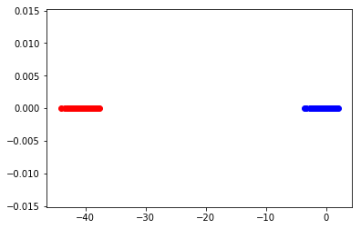

```python
from matplotlib.pyplot import scatter
import matplotlib.pyplot as plt
from scipy.sparse.linalg import eigs

K = 1
X = Q3_solution()

Sigma = np.cov(X.T)
S11 = np.linalg.pinv(Sigma[0:50,0:50])
S22 = np.linalg.pinv(Sigma[50:100,50:100])
S12 = Sigma[0:50,50:100]
S21 = Sigma[50:100,0:50]


M = S11.dot(S12.dot(S22.dot(S21)))
E, W = eigs(M,k=K,which='LM')
W = np.real(W)


XX = X[:,0:50]
mu = np.mean(XX)


Y1 = XX.dot(W)


plt.figure(0)
plt.scatter(Y1[0:500],np.zeros((500,1)),color='blue')
plt.scatter(Y1[500:1000],np.zeros((500,1)),color='red')
plt.show()
```

# Now we do PCA on each view and reduce by just one dimension!

We project from 50 to 49 for each fo teh views and then do CCA and project say view 1 to one dimension via CCA. Lets see the result.

If you worked out the problem right, you should see the red abd blue dots are all mixed up and not separated

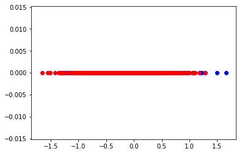

```python
K = 49
Sigma = np.cov(X.T)
E1, W1 = np.linalg.eig(Sigma[0:50,0:50])
E2, W2 = np.linalg.eig(Sigma[50:100,50:100])
idx = E1.argsort()[::-1]
E1 = E1[idx]
W1 = W1[:,idx]
idx = E2.argsort()[::-1]
E2 = E2[idx]
W2 = W2[:,idx]

W1 = np.real(W1[0:50,0:49])
W2 = np.real(W2[0:50,0:49])

XX1 = X[:,0:50].dot(W1)
XX2 = X[:,50:100].dot(W2)

XX = np.zeros((1000,98))
XX[:,0:49] = XX1
XX[:,49:98] = XX2

K = 1

Sigma = np.cov(XX.T)
S11 = np.linalg.pinv(Sigma[0:49,0:49])
S22 = np.linalg.pinv(Sigma[49:98,49:98])
S12 = Sigma[0:49,49:98]
S21 = Sigma[49:98,0:49]


M = S11.dot(S12.dot(S22.dot(S21)))
E, W = eigs(M,k=K,which='LM')
W = np.real(W)


XXX = XX[:,0:49]

Y1 = XXX.dot(W)

plt.figure(1)
scatter(Y1[0:500],np.zeros((500,1)),color='blue')
scatter(Y1[500:1000],np.zeros((500,1)),color='red')
plt.show()
```